# IS 605 FUNDAMENTALS OF COMPUTATIONAL MATHEMATICS - WEEK 8 | Data Analytics

Author:MUSA T GANIYU

Question 1:

Your colleague either commutes by train or by the bus. 20 days of the month, she takes the train and the remaining 10 days she takes the bus. If she takes the train, she reaches work on time with a probability of 0.9. If she takes the bus, she frequently gets stuck in traffic and reaches work on time with a probability of 0.5. Given that she was on time today, what is the probability that she took the bus to work today?

Recall:

$Pr(A|B)\quad =\frac { Pr(B|A).Pr(A) }{ Pr(B) } \quad =\quad \frac { Pr(B|A).Pr(A) }{ Pr(B|A).Pr(A)\quad +\quad Pr(B|A\prime ).Pr(A\prime ) }$

Where Pr(Train 20 days in a month)= 20/30 = 0.6667i.e total number of days in a month.

Pr(Bus 20 days in a month) = 10/30 = 0.3333

Pr(Train on time) = 0.9000, Pr(Train not on time) = 0.1000

Pr(Bus on time) = 0.5, Pr(Bus not on time) = 0.5

Therefore,

```r
Prob_Train_on_time_for_20days <- 0.6667 * 0.9000

Prob_Bus_on_time_for_10days <-  0.3333*0.5

# While

Prob_not_Train_on_time_for_20days <- 0.6667 * 0.1000

Prob_not_Bus_on_time_for_10days <-  0.3333*0.5


Prob_of_bus_to_work_on_time_today <- (Prob_Bus_on_time_for_10days) / (Prob_Bus_on_time_for_10days + Prob_Train_on_time_for_20days)
Prob_of_bus_to_work_on_time_today
```

```
## [1] 0.2173658
```

```r
# Or
suppressWarnings(suppressMessages(require(LaplacesDemon)))

PrA <- c(0.9000,0.5000)
PrBA <- c(0.6667, 0.3333)
BayesTheorem(PrA, PrBA)
```

```
## [1] 0.7826342 0.2173658
## attr(,"class")
## [1] "bayestheorem"
```

> Question 2:

In the Grade Network that we looked at in the notes…….You should use the gRain package in R to build your network and perform these calculations. You may need to install RBGL package from BioConductor in R to get gRain working.

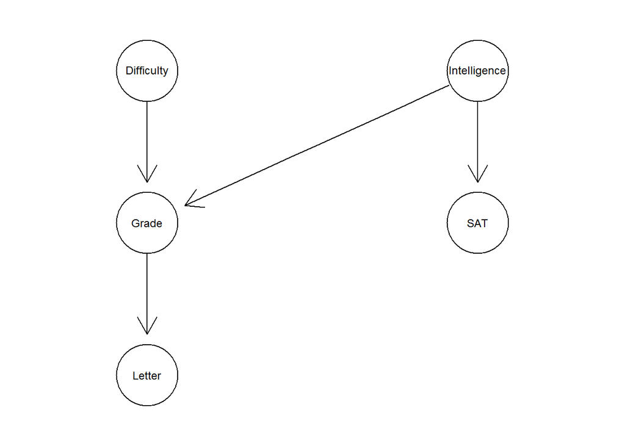

```r
suppressWarnings(suppressMessages(require(gRain)))
suppressWarnings(suppressMessages(library(Rgraphviz)))


ny <- c("no", "yes")
lh <- c("low", "high")
d <- cptable(~Difficulty, values=c(0.3,0.7), levels = ny)
i <- cptable(~Intelligence, values = c(0.8, 0.2), levels = lh)
s.i <- cptable(~SAT|Intelligence, values = c(0.9,0.1,0.2,0.8), levels = lh)
g.di <- cptable(~Grade|Difficulty:Intelligence, values=c(0.6,0.4,0.8,0.2,0.1,0.99,0.1,0.9), levels = lh)
l.g <- cptable(~Letter|Grade, values=c(0.9,0.1,0.5,0.95), levels = lh)

plist <- compileCPT(list(d, i, s.i, g.di, l.g))

pn <- grain(plist)
plot(pn)
```

> Question 2.1:

What happens to the probability of Diffculty of Course when you present the evidence that the received recommendation letter was good?

```r
Letter.f <- setFinding(pn, nodes = c("Letter"), states=c("High"))
(querygrain(Letter.f, nodes=c("Difficulty"), type="marginal"))
```

```
## $Difficulty
## Difficulty
##  no yes
## 0.3 0.7
```

> Question 2.2:

In addition, now present the evidence that both SAT scores were good and the letter of recommendation was good, What is the probability of the Diffculty of Course now?

```r
SAT.f <- setFinding(Letter.f, nodes=c("SAT"), states=c("High"))
(querygrain(SAT.f, nodes=c("Difficulty"), type="marginal"))
```

```
## $Difficulty
## Difficulty
##  no yes
## 0.3 0.7
```

It further revealed that both SAT scores and Letter of recommendation were good, with the probability of Difficulty of course still at 70 percent.